# Sally the Congressperson: A Psycho- and Sociolinguistic Investigation into the Relationship Between Ideology, Gender, and Language

B. Papineau

Autumn 2021

# 1 Introduction

The code and information contained herein constitutes the complete write-up of the experiments I carried out for my first Qualifying Paper towards the PhD in Linguistics at Stanford University. The goal is to make this document both a dumping ground for my ideas while it is in progress, as well as, eventually, a publicly-available version of my Qualifying Paper, in the spirit of Open Science.

## 1.1 Preliminaries

### 1.1.1 Setting up the Notebook

For this write-up and analysis, I require the following packages, loaded in here:

```r
library(ggplot2)
library(tidyverse)
library(lme4)
library(stringr)
library(languageR)
library(lmerTest)
library(reshape2)
library(grid)

source("helpers.R")
```

I also use a custom color palette, so I include the code for that here as well[^1].

```r
bran_palette = c("#7ae7e5", "#fe5f55", "#B2A6DE", "#14342b", "#69385c")

theme_set(theme_minimal())
```

### 1.1.2 Frequency Data

We also need the frequency data!

```r
frequency <- read.csv("freq_vals.csv")
```

```r
lib_cols <- c('ABC','CNN','PBS','NBC','MSNBC','NPR','CBS')
```

```r
frequency <- frequency %>%
  mutate(total_left = rowSums(frequency[lib_cols])) %>%
  mutate(total_right = FOX) %>%
  mutate(left_wpm = (total_left/109300000) * 1000000) %>%
  mutate(right_wpm = (total_right/12200000) * 1000000) %>%
  mutate(neutral_binary = ifelse(gender=="neutral",1,0)) %>%
  mutate(morph_type = ifelse(lexeme!= 'actor' & lexeme!= 'host' & lexeme !='hunter' & lexeme!= 'villain' & lexeme!= 'heir' & lexeme!= 'hero','compound','adoption'))
```

```r
frequency_grouped <- frequency %>%
  filter(morph_type=="compound") %>%
  group_by(lexeme,neutral_binary) %>%
  summarise(mean_freq_left = mean(left_wpm), mean_freq_right = mean(right_wpm))
```

```r
write.csv(frequency_grouped, "freq_prep.csv")
```

```r
lex_freqs <- read.csv("freq_preped.csv") %>%
  mutate(left_surprisal = (-log(mean_left_neutral))/(-log(mean_left_gendered))) %>%
  mutate(right_surprisal = (-log(mean_right_neutral))/(-log(mean_right_gendered)))
```

# 2 Experiments

## 2.1 Norming Study

### 2.1.1 Methods

**Participants**

100 participants were recruited through the online recruitment platform Prolific. All participants were self-identified L1 English speakers and were born and resided in the United States at the time of participation. None of the participants had participated in the 4-person pilot of the norming study, and the pilot data is not reported here.

**Experiment**

A link to the experiment can be found [here](https://branpap.github.io/gender_processing/experiments/norming_study_one/experiment.html), and is available for the keen reader to click through; results are not stored in any way.

### 2.1.2 Analysis

**Reading in the Data**

I read in the data here, as well as including some upfront filters and mutations. Their individual purposes are provided in accompanying comments.

```r
norming_data <- read.csv("norming_data.csv") %>%
  filter(id!="example1") %>% # Will filter out non-critical trials, i.e. the example trial from the beginning of the experiment
  mutate(equalized_response = ifelse(scale=="FM",8-response,response)) %>% # This will render all data points on the same scale, as participants randomly received either "very likely a man" or "very likely a woman" as the left end of their response scale, with the other appearing at the right end
  mutate(orthog = ifelse(orthog=="sroceress","sorceress",orthog)) %>% # Fixes a typo
  mutate(id = ifelse(id=="Stunt_double","Stunt double",id)) %>% # This, as well as all lines below it, convert compounds formed by spaces from their underscore forms to their spaced forms (e.g. police_officer -> Police officer)
  mutate(id = ifelse(id=="Restaurant_server","Restaurant server",id)) %>%
  mutate(id = ifelse(id=="Police_officer","Police officer",id)) %>%
  mutate(id = ifelse(id=="Door_attendant","Door attendant",id)) %>%
  mutate(id = ifelse(id=="Flight_attendant","Flight attendant",id)) %>%
  mutate(id = ifelse(id=="Garbage_Collector","Garbage collector",id)) %>%
  mutate(id = ifelse(id=="Mail_Carrier","Mail carrier",id)) %>%
  mutate(id = ifelse(id=="Maintenance_Person","Maintenance person",id)) %>%
  mutate(id = ifelse(id=="Paper_carrier","Paper carrier",id))
```

**Generating an Exclusion List**

```r
norming_exclusion <- norming_data %>%
  filter(gender=="female") %>%
  group_by(workerid) %>%
  summarize(female_mean = mean(equalized_response)) %>%
  unique() %>%
  mutate(exclusion = female_mean < mean(female_mean) - 2*sd(female_mean)) %>%
  filter(exclusion==TRUE)
```

Now I can exclude these participants from the data under analysis.

```r
norming_data <- norming_data[!(norming_data$workerid %in% norming_exclusion$workerid),]
```

**Means by Item**

```r
norming_means <- norming_data %>%
  group_by(id,gender,orthog) %>%
  summarise(indi_mean = mean(equalized_response), trial_count=n())
```

```r
text_high <- textGrob("Female", gp=gpar(fontsize=10, fontface="bold"))
text_low <- textGrob("Male", gp=gpar(fontsize=10, fontface="bold"))
```

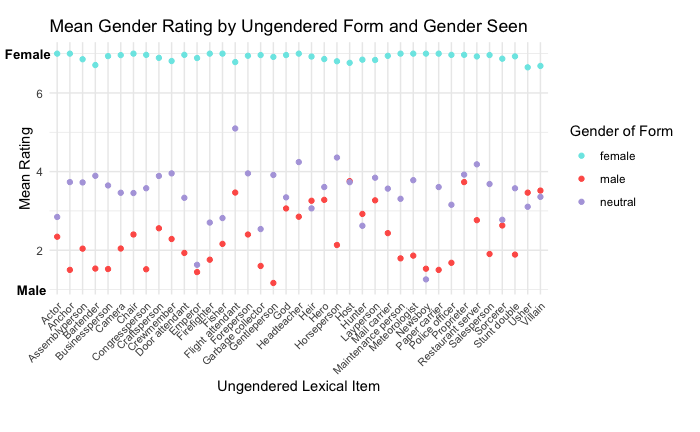

```r
ggplot(norming_means, aes(x=id, y=indi_mean, color=gender)) +
  geom_point() +
  theme_minimal() +
  theme(axis.text.x = element_text(angle=45, hjust=1, size=8)) +
  labs(x="Ungendered Lexical Item", y="Mean Rating", color = "Gender of Form", title="Mean Gender Rating by Ungendered Form and Gender Seen") +
  scale_color_manual(values = bran_palette) +
  theme(plot.margin = unit(c(1,1,2,1), "lines")) +
  annotation_custom(text_high,xmin=-1.3,xmax=-1.3,ymin=7,ymax=7) +
  annotation_custom(text_low,xmin=-1,xmax=-1,ymin=1,ymax=1) +
  coord_cartesian(clip = "off")
```

## 2.2 Self-Paced Reading Study

### 2.2.1 Methods

**Participants**

We originally ran the experiment on 200 participants, recruited through the online participant recruitment platform [Prolific](https://www.prolific.co). The mean time of the experiment was 5.39 minutes, and participants were paid $1.75 for their participation[^2]. The only restrictions placed on participants were that they:

1. Were born in the United States
2. Lived in the United States at the time of participation
3. Spoke English as a first language
4. Had not participated in the norming study for the stimuli

These requirements were implemented in order to assure that speakers came from at least somewhat similar linguistic backgrounds, as certain lexical items in the study (such as *congressperson*) are quite localized to the United States.

After this initial run of the experiment, we found that there was a dearth of conservative or Republican-aligned participants. As a result, we ran the experiment again, this time on 98 self-identified Republicans. This was achieved by adding a filter on Prolific so that only Republican-identified individuals could see the task. The rest of the experiment, including payment, was exactly the same, except that an additional disclaimer that participants could not use the FireFox browser experiment, after the first run revealed an incompatibility between JavaScript and FireFox. The two runs of the experiment amounted in a total of 298 participants who completed the task.

### 2.2.2 Analysis

**Reading in the Data**

```r
sprt_data <- read.csv('sprt_data.csv') %>%
  filter(trial_id!= 'example') %>%
  filter(region=='critical')
```

**Exclusions**

Now, we want to exclude any participants who failed to answer at least 85% of the attention check questions correctly. We do this by creating a list of all participants who scored less than 85% on these checks, and then cross-referencing this list with all data points, removing any data points whose participants were in the exclusion list.

```r
sprt_exclusion <- sprt_data %>% group_by(workerid) %>%
  summarise(accuracy = mean(response_correct)) %>%
  mutate(exclude = ifelse(accuracy < 0.85,'Yes','No')) %>%
  filter(exclude == 'Yes')

sprt_data <- sprt_data[!(sprt_data$workerid %in% sprt_exclusion$workerid),]
```

```r
sprt_data <- sprt_data %>%
  group_by(trial_id) %>%
  mutate(id_mean = mean(log(rt))) %>%
  mutate(exclusion = (log(rt) < mean(log(rt)) - 2*sd(log(rt))|(log(rt) > mean(log(rt)) + 2*sd(log(rt))))) %>%
  ungroup() %>%
  filter(exclusion==FALSE)
```

This results in 238 trials being removed from the 5580 we got after the by-participant exclusions. We now have 5342 trials we can use for analysis.

**Additional Information** Now that we have only the rows we want, let’s add some new columns, which will contain important information for each data point. Here, we will be adding:

- Gender Ideology Subscores
- Trial Genders
- Trial Morphology Types
- Critical Item Length & Length-Controlled Residuals
- Trial Congruency
- Partipant Political Affiliation

Ideally, I would’ve added all of these but the first when I actually created the stimuli and logged responses, but I forgot to! Luckily, R allows us to do this post-hoc fairly straightforwardly… which is good, since these features will be critical in our data visualization and analysis.

The question under investigation here is whether or not individuals’ conceptions of gender affect how they process gendered and gender-neutral forms of English personal and professional titles.  
In order to examine this, we need to quanify participants’ ideological views! Here we have adopted the 13-item Social Roles Questionnaire put forth in Baber & Tucker (2006). Questions 1-5 correlate to the *‘Gender Transcendent’* subscale, and questions 6-13 correspond to the *‘Gender Linked’* subscale. Each item is scored on a scale of 0-100. So, the first thing we want to do is make two lists of columns which correspond to these two subscales, since the questions are stored individually in the data:

```r
gender_transcendence_cols <- c('subject_information.gender_q1','subject_information.gender_q2','subject_information.gender_q3','subject_information.gender_q4','subject_information.gender_q5')

gender_linked_cols <- c('subject_information.gender_q6','subject_information.gender_q7','subject_information.gender_q8','subject_information.gender_q9','subject_information.gender_q10','subject_information.gender_q11','subject_information.gender_q12','subject_information.gender_q13')
```

Now we can use the mutate() method on **sprt_data** to add two new columns, one for each subscale. We tell R to take the means of the specified columns in [column_names] of **sprt_data** for each individual row: rowMeans(sprt_data[column_names]). We also have to subtract this mean from 100 in the case of the *‘Gender Transcendent’* subscale, since it is inversely scored. Finally, we can create an average total score regardless of subscores, simply by meaning the two subscores we already have.

```r
sprt_data <- sprt_data %>%
  mutate(gender_trans = 100 - (rowMeans(sprt_data[gender_transcendence_cols]))) %>%
  mutate(gender_link = rowMeans(sprt_data[gender_linked_cols]))

gender_all = c('gender_trans','gender_link')

sprt_data <- sprt_data %>%
  mutate(gender_total = rowMeans(sprt_data[gender_all]))
```

We also want to add whether the trial included a female or male referent (but also, like, destroy the binary!). In order to do this, we’ll just add a **trial_gender** column that says *‘female’* if the condition was either *‘neutral_female’* or *‘congruent_female’*. Otherwise, we want the **trial_gender** to say *‘male’*.

```r
sprt_data <- sprt_data %>%
  mutate(trial_gender = ifelse(condition=='neutral_female' | condition == 'congruent_female','female','male'))

sprt_data %>%
  select(workerid,rt,condition,trial_id,trial_gender)
```

| workerid | rt | condition | trial_id | trial_gender |
| --- | --- | --- | --- | --- |
| 201 | 392 | congruent_female | hero_congruent_female | female |
| 201 | 344 | congruent_female | businessperson_congruent_female | female |
| 201 | 368 | neutral_female | heir_neutral_female | female |
| 201 | 480 | congruent_female | anchor_congruent_female | female |
| 201 | 400 | congruent_male | salesperson_congruent_male | male |
| 201 | 265 | congruent_male | crewmember_congruent_male | male |
| 201 | 344 | congruent_female | stunt double_congruent_female | female |
| 201 | 504 | neutral_male | actor_neutral_male | male |
| 201 | 304 | neutral_male | meteorologist_neutral_male | male |
| 201 | 384 | neutral_female | police officer_neutral_female | female |

[output cut: 990 more lines]

Now we want to add whether or not the lexeme’s neutral form is developed by compounding (as in *‘congress-person’*) or by the adoption of the male form (as in *‘actor’* being used more for both men and women). In this study, we only have six lexemes of the latter type, so we’ll just tell R to assign those a **morph_type** value of *‘adoption’* (for ‘male adoption’), and all else will be assigned a value of *‘compound’*.

```r
sprt_data <- sprt_data%>%
  mutate(morph_type = ifelse(lexeme!= 'actor' & lexeme!= 'host' & lexeme !='hunter' & lexeme!= 'villain' & lexeme!= 'heir' & lexeme!= 'hero','compound','adoption'))

sprt_data %>%
  select(rt,lexeme,morph_type)
```

| rt | lexeme | morph_type |
| --- | --- | --- |
| 392 | hero | adoption |
| 344 | businessperson | compound |
| 368 | heir | adoption |
| 480 | anchor | compound |
| 400 | salesperson | compound |
| 265 | crewmember | compound |
| 344 | stunt double | compound |
| 504 | actor | adoption |
| 304 | meteorologist | compound |
| 384 | police officer | compound |

[output cut: 990 more lines]

Another important factor we want to explore is the length of the critical item! In order to add this, we simply create a new column **form_length** and tell R to input as that column’s value the length of the string that appears in that row’s **form** column, which corresponds to the orthograpic form of the critical item in that trial. *Note that this will include spaces in the count!*

```r
sprt_data <- sprt_data %>%
  mutate(form_length = str_length(form))

sprt_residual_model <- lm(log(rt)~form_length, data = sprt_data)

sprt_data <- sprt_data %>%
  mutate(resid_rt = resid(sprt_residual_model))
```

Now that we have these, we can run a simple linear regression which will show us the effect of orthographic length on reading time. Then we add a new column in the data which is the residual reading time, or the reading time in log space AFTER we control for the effects of orthographic length.

We also want to make sure we have a column which records whether or not the trial was gender-congruent (as in *‘Shelby is a congresswoman’*) or gender neutral (as in *‘Shelby is a congressperson’*). We add a **trial_congruency** column, which is valued as *‘congruent’* if that row’s condition is one of the two congruent conditions. Otherwise, it gets valued as *‘neutral’*.

```r
sprt_data <- sprt_data %>%
  mutate(trial_congruency = ifelse(condition=='congruent_male' | condition == 'congruent_female','congruent','neutral'))
```

Finally, we can classify participants by their particular political alignment; we can construe this broadly as “Republicans” vs. “Democrats”, with those who declined to state a preference, or placed themselves in the middle, as “Non-Partisan”.

```r
sprt_data <- sprt_data %>%
  mutate(poli_party = ifelse(subject_information.party_alignment == 1 | subject_information.party_alignment == 2,'Republican',ifelse(subject_information.party_alignment == 4 | subject_information.party_alignment == 5,'Democrat','Non-Partisan')))
```

**Speaker Means**

```r
sprt_speaker_means <- sprt_data %>%
  group_by(condition,poli_party,workerid) %>%
  summarize(MeanRT=mean(resid_rt))
```

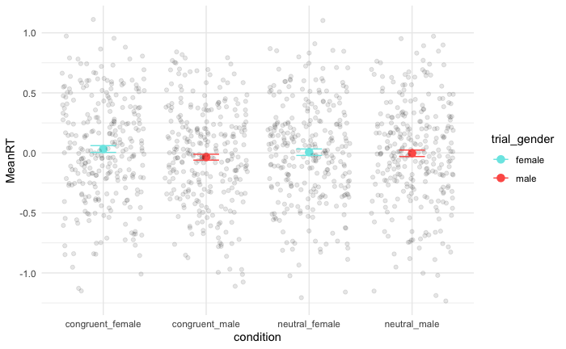

```r
sprt_data %>%
  group_by(condition,trial_gender) %>%
  summarize(MeanRT = mean(resid_rt), CI.Low = ci.low(resid_rt), CI.High = ci.high(resid_rt)) %>%
  mutate(YMin = MeanRT - CI.Low, YMax = MeanRT + CI.High) %>%
  ggplot(aes(x=condition,y=MeanRT,color=trial_gender)) +
  geom_point(size=3) +
  geom_jitter(data = sprt_speaker_means, aes(y=MeanRT),alpha=.1,color='black') +
  geom_errorbar(aes(ymin=YMin,ymax=YMax), width=.25) +
  scale_color_manual(values = bran_palette, )
```

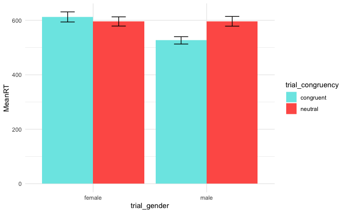

```r
sprt_whole_means <- sprt_data %>%
  group_by(trial_gender,trial_congruency) %>%
  summarize(MeanRT = mean(rt), CI.Low = ci.low(rt), CI.High = ci.high(rt)) %>%
  mutate(YMin = MeanRT - CI.Low, YMax = MeanRT + CI.High)
dodge = position_dodge(.9)
ggplot(data=sprt_whole_means, aes(x=trial_gender,y=MeanRT,fill=trial_congruency)) +
  geom_bar(stat='identity',position=dodge) +
  geom_errorbar(aes(ymin=YMin,ymax=YMax),width=.25,position=dodge) +
  scale_fill_manual(values = bran_palette)
```

**Reading Time by Gender Ideology**

```r
sprt_speaker_means_ideology <- sprt_data %>%
  group_by(gender_link,workerid,trial_gender,trial_congruency,poli_party) %>%
  summarise(meanrt = mean(resid_rt))
```

[output not shown]

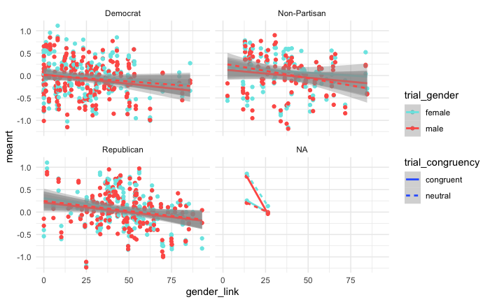

```r
sprt_speaker_means_ideology %>%
  ggplot(aes(x=gender_link,y=meanrt,color=trial_gender,linetype=trial_congruency)) +
  geom_point() +
  geom_smooth(method='lm') +
  scale_color_manual(values = bran_palette, ) +
  facet_wrap(~poli_party)
```

**Reading Time on Neologisms**

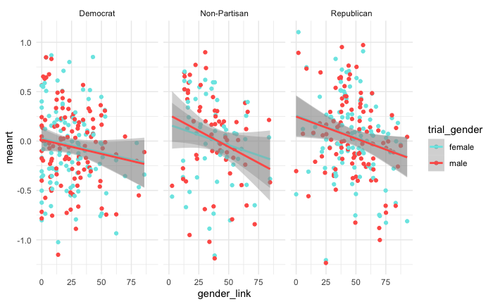

```r
sprt_data %>%
  filter(!is.na(poli_party)) %>%
  filter(trial_congruency == "neutral") %>%
  group_by(gender_link,workerid,trial_gender,poli_party) %>%
  summarise(meanrt = mean(resid_rt)) %>%
  ggplot(aes(x=gender_link,y=meanrt,color=trial_gender)) +
  geom_point() +
  geom_smooth(method='lm') +
  scale_color_manual(values = bran_palette, ) +
  facet_wrap(~poli_party)
```

**Reading Time by Item**

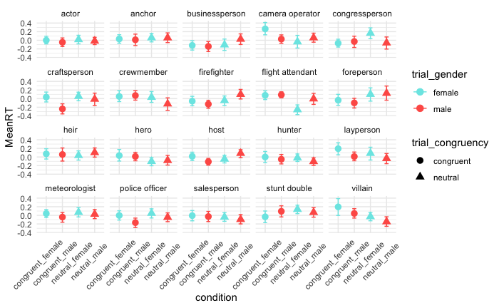

```r
sprt_data %>%
  group_by(condition,trial_gender,trial_congruency,lexeme) %>%
  summarize(MeanRT = mean(resid_rt), CI.Low = ci.low(resid_rt), CI.High = ci.high(resid_rt)) %>%
  mutate(YMin = MeanRT - CI.Low, YMax = MeanRT + CI.High) %>%
  ggplot(aes(x=condition,y=MeanRT,color=trial_gender,shape=trial_congruency)) +
  geom_point(size=3) +
  geom_errorbar(aes(ymin=YMin,ymax=YMax), width=.25) +
  facet_wrap(~ lexeme) +
  theme(axis.text.x = element_text(angle = 45, vjust = .7, hjust=.7)) +
  scale_color_manual(values = bran_palette)
```

**Whole-Party Means**

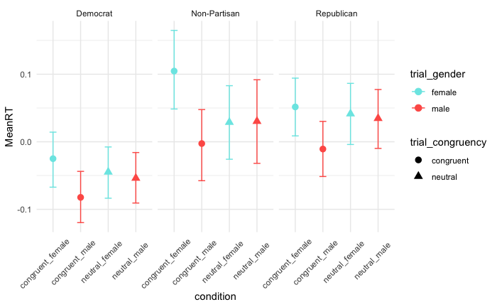

```r
sprt_data %>%
  filter(!is.na(poli_party)) %>%
  group_by(poli_party,condition,trial_gender,trial_congruency) %>%
  summarize(MeanRT = mean(resid_rt), CI.Low = ci.low(resid_rt), CI.High = ci.high(resid_rt)) %>%
  mutate(YMin = MeanRT - CI.Low, YMax = MeanRT + CI.High) %>%
  ggplot(aes(x=condition,y=MeanRT,color=trial_gender,shape=trial_congruency)) +
  geom_point(size=3) +
  geom_errorbar(aes(ymin=YMin,ymax=YMax), width=.25) +
  facet_wrap(~ poli_party, nrow = 1) +
  theme(axis.text.x = element_text(angle = 45, vjust = .7, hjust=.7)) +
  scale_color_manual(values = bran_palette)
```

**Modelling**

```r
sprt_final_dat <- merge(sprt_data,lex_freqs,by="lexeme") %>%
  mutate(cgender_total = scale(gender_total)) %>%
  mutate(cage = scale(subject_information.age)) %>%
  mutate(cmean_left_neutral = scale(mean_left_neutral)) %>%
  mutate(mean_all = (mean_left_neutral + mean_right_neutral)/2) %>%
  mutate(cmean_all = scale(mean_all)) %>%
  mutate(ctrial_congruency = as.numeric(as.factor(trial_congruency))-mean(as.numeric(as.factor(trial_congruency)))) %>%
  mutate(ctrial_gender = as.numeric(as.factor(trial_gender))-mean(as.numeric(as.factor(trial_gender))))
```

```r
complex_model <- lmer(resid_rt~ctrial_congruency*cgender_total*poli_party*cmean_all + (1|workerid) + (1|lexeme) + (1|name),data = sprt_final_dat)
```

```r
summary(complex_model)
```

```
Linear mixed model fit by REML. t-tests use Satterthwaite's method ['lmerModLmerTest']
Formula: resid_rt ~ ctrial_congruency * cgender_total * poli_party * cmean_all +      (1 | workerid) + (1 | lexeme) + (1 | name)
   Data: sprt_final_dat

REML criterion at convergence: 2983.4

Scaled residuals:
    Min      1Q  Median      3Q     Max
-3.9865 -0.5941 -0.0460  0.5125  4.4044

Random effects:
 Groups   Name        Variance  Std.Dev.
 workerid (Intercept) 0.1531582 0.39135
 name     (Intercept) 0.0007211 0.02685
 lexeme   (Intercept) 0.0019161 0.04377
 Residual             0.0998232 0.31595
Number of obs: 3713, groups:  workerid, 275; name, 24; lexeme, 14

Fixed effects:
                                                                   Estimate Std. Error         df t value Pr(>|t|)
(Intercept)                                                      -8.711e-02  4.823e-02  2.726e+02  -1.806  0.07196 .
ctrial_congruency                                                 8.878e-03  2.036e-02  3.411e+03   0.436  0.66275
cgender_total                                                    -6.397e-02  5.012e-02  2.669e+02  -1.276  0.20296
poli_partyNon-Partisan                                            1.270e-01  7.020e-02  2.668e+02   1.809  0.07157 .
poli_partyRepublican                                              1.954e-01  6.489e-02  2.672e+02   3.011  0.00285 **
cmean_all                                                        -2.990e-03  1.542e-02  2.580e+01  -0.194  0.84779
ctrial_congruency:cgender_total                                   1.106e-02  2.204e-02  3.420e+03   0.502  0.61568
ctrial_congruency:poli_partyNon-Partisan                         -1.286e-02  3.069e-02  3.413e+03  -0.419  0.67520
ctrial_congruency:poli_partyRepublican                            1.080e-02  2.853e-02  3.412e+03   0.379  0.70494
cgender_total:poli_partyNon-Partisan                             -1.629e-02  7.267e-02  2.669e+02  -0.224  0.82276
cgender_total:poli_partyRepublican                               -6.669e-02  6.541e-02  2.671e+02  -1.019  0.30890
ctrial_congruency:cmean_all                                       3.509e-03  2.092e-02  3.423e+03   0.168  0.86678
cgender_total:cmean_all                                          -3.001e-03  1.088e-02  3.395e+03  -0.276  0.78264
poli_partyNon-Partisan:cmean_all                                  2.016e-02  1.529e-02  3.400e+03   1.319  0.18729
poli_partyRepublican:cmean_all                                    5.686e-03  1.417e-02  3.399e+03   0.401  0.68823
ctrial_congruency:cgender_total:poli_partyNon-Partisan           -6.888e-02  3.187e-02  3.415e+03  -2.161  0.03073 *
ctrial_congruency:cgender_total:poli_partyRepublican             -1.059e-02  2.872e-02  3.412e+03  -0.369  0.71229
ctrial_congruency:cgender_total:cmean_all                         1.584e-02  2.243e-02  3.425e+03   0.706  0.48006
ctrial_congruency:poli_partyNon-Partisan:cmean_all                3.462e-03  3.157e-02  3.422e+03   0.110  0.91267
ctrial_congruency:poli_partyRepublican:cmean_all                 -1.306e-02  2.938e-02  3.423e+03  -0.445  0.65665
cgender_total:poli_partyNon-Partisan:cmean_all                    3.021e-03  1.590e-02  3.399e+03   0.190  0.84932
cgender_total:poli_partyRepublican:cmean_all                     -2.510e-03  1.417e-02  3.400e+03  -0.177  0.85941
ctrial_congruency:cgender_total:poli_partyNon-Partisan:cmean_all -1.828e-02  3.282e-02  3.422e+03  -0.557  0.57753
ctrial_congruency:cgender_total:poli_partyRepublican:cmean_all   -7.961e-04  2.921e-02  3.423e+03  -0.027  0.97826
---
Signif. codes:  0 ‘***’ 0.001 ‘**’ 0.01 ‘*’ 0.05 ‘.’ 0.1 ‘ ’ 1
```

```
Correlation matrix not shown by default, as p = 24 > 12.
Use print(x, correlation=TRUE)  or
    vcov(x)        if you need it
```

## 2.3 MAZE-Task Study

### 2.3.1 Methods

### 2.3.2 Analysis

**Data Read-in**

```r
maze_data <- read.csv('maze_data.csv') %>%
  filter(trial_id!= 'example') %>%
  filter(region=='critical')
```

**Running Exclusion Criteria** Now, we want to exclude any participants who failed to answer at least 80% of the attention check questions correctly. We do this by creating a list of all participants who scored less than 80% on these checks, and then cross-referencing this list with all data points, removing any data points whose participants were in the exclusion list.

```r
maze_exclusion <- maze_data %>% group_by(workerid) %>%
  summarise(accuracy = mean(response_correct)) %>%
  mutate(exclude = ifelse(accuracy < 0.80,'Yes','No')) %>%
  filter(exclude == 'Yes')

maze_data <- maze_data[!(maze_data$workerid %in% maze_exclusion$workerid),] %>%
  filter(rt !='null')
```

```r
maze_data <- maze_data %>%
  group_by(trial_id) %>%
  mutate(id_mean = mean(log(rt))) %>%
  mutate(exclusion = (log(rt) < mean(log(rt)) - 2*sd(log(rt))|(log(rt) > mean(log(rt)) + 2*sd(log(rt))))) %>%
  ungroup() %>%
  filter(exclusion==FALSE)
```

**Additional Information**

```r
maze_data <- maze_data %>%
  mutate(gender_trans = 100 - (rowMeans(maze_data[gender_transcendence_cols]))) %>%
  mutate(gender_link = rowMeans(maze_data[gender_linked_cols]))

gender_all = c('gender_trans','gender_link')

maze_data <- maze_data %>%
  mutate(gender_total = rowMeans(maze_data[gender_all]))
```

### 2.3.3 Adding Gender

We also want to add whether the trial included a female or male referent (but also, like, destroy the binary!). In order to do this, we’ll just add a **trial_gender** column that says *‘female’* if the condition was either *‘neutral_female’* or *‘congruent_female’*. Otherwise, we want the **trial_gender** to say *‘male’*.

```r
maze_data <- maze_data %>%
  mutate(trial_gender = ifelse(condition=='neutral_female' | condition == 'congruent_female','female','male'))

maze_data %>%
  select(workerid,rt,condition,trial_id,trial_gender)
```

| workerid | rt | condition | trial_id | trial_gender |
| --- | --- | --- | --- | --- |
| 489 | 2532 | neutral_female | congressperson_neutral_female | female |
| 489 | 1526 | congruent_male | meteorologist_congruent_male | male |
| 489 | 1504 | congruent_male | layperson_congruent_male | male |
| 489 | 1305 | congruent_female | anchor_congruent_female | female |
| 489 | 1155 | congruent_female | foreperson_congruent_female | female |
| 489 | 1154 | congruent_female | businessperson_congruent_female | female |
| 489 | 1225 | congruent_male | host_congruent_male | male |
| 489 | 1973 | congruent_female | craftsperson_congruent_female | female |
| 489 | 1467 | congruent_male | stunt double_congruent_male | male |
| 489 | 2211 | neutral_male | police officer_neutral_male | male |

[output cut: 990 more lines]

### 2.3.4 Adding Morphology Type

Now we want to add whether or not the lexeme’s neutral form is developed by compounding (as in *‘congress-person’*) or by the adoption of the male form (as in *‘actor’* being used more for both men and women). In this study, we only have six lexemes of the latter type, so we’ll just tell R to assign those a **morph_type** value of *‘adoption’* (for ‘male adoption’), and all else will be assigned a value of *‘compound’*.

```r
maze_data <- maze_data%>%
  mutate(morph_type = ifelse(lexeme!= 'actor' & lexeme!= 'host' & lexeme !='hunter' & lexeme!= 'villain' & lexeme!= 'heir' & lexeme!= 'hero','compound','adoption'))

maze_data %>%
  select(rt,lexeme,morph_type)
```

| rt | lexeme | morph_type |
| --- | --- | --- |
| 2532 | congressperson | compound |
| 1526 | meteorologist | compound |
| 1504 | layperson | compound |
| 1305 | anchor | compound |
| 1155 | foreperson | compound |
| 1154 | businessperson | compound |
| 1225 | host | adoption |
| 1973 | craftsperson | compound |
| 1467 | stunt double | compound |
| 2211 | police officer | compound |

[output cut: 990 more lines]

### 2.3.5 Adding Form Length & Length-Controlled Residuals

Another important factor we want to explore is the length of the critical item! In order to add this, we simply create a new column **form_length** and tell R to input as that column’s value the length of the string that appears in that row’s **form** column, which corresponds to the orthograpic form of the critical item in that trial. *Note that this will include spaces in the count!*

```r
maze_data <- maze_data %>%
  mutate(form_length = str_length(form))

simple_model <- lm(log(rt)~form_length, data = maze_data)

maze_data <- maze_data %>%
  mutate(resid_rt = resid(simple_model))
```

```r
summary(simple_model)
```

```
Call:
lm(formula = log(rt) ~ form_length, data = maze_data)

Residuals:
     Min       1Q   Median       3Q      Max
-0.83975 -0.27384 -0.05032  0.23306  1.56914

Coefficients:
            Estimate Std. Error t value Pr(>|t|)
(Intercept)  6.92941    0.01911 362.644  < 2e-16 ***
form_length  0.01099    0.00196   5.608 2.21e-08 ***
---
Signif. codes:  0 ‘***’ 0.001 ‘**’ 0.01 ‘*’ 0.05 ‘.’ 0.1 ‘ ’ 1

Residual standard error: 0.3638 on 3269 degrees of freedom
Multiple R-squared:  0.00953,   Adjusted R-squared:  0.009227
F-statistic: 31.45 on 1 and 3269 DF,  p-value: 2.212e-08
```

Now that we have these, we can run a simple linear regression which will show us the effect of orthographic length on reading time. Then we add a new column in the data which is the residual reading time, or the reading time in log space AFTER we control for the effects of orthographic length.

### 2.3.6 Adding Congruency Column

We also want to make sure we have a column which records whether or not the trial was gender-congruent (as in *‘Shelby is a congresswoman’*) or gender neutral (as in *‘Shelby is a congressperson’*). We add a **trial_congruency** column, which is valued as *‘congruent’* if that row’s condition is one of the two congruent conditions. Otherwise, it gets valued as *‘neutral’*.

```r
maze_data <- maze_data %>%
  mutate(trial_congruency = ifelse(condition=='congruent_male' | condition == 'congruent_female','congruent','neutral'))
```

### 2.3.7 Adding Large Political Macrocategories

Finally, we can classify participants by their particular political alignment; we can construe this broadly as “Republicans” vs. “Democrats”, with those who declined to state a preference, or placed themselves in the middle, as “Non-Partisan”.

```r
maze_data <- maze_data %>%
  mutate(poli_party = ifelse(subject_information.party_alignment == 1 | subject_information.party_alignment == 2,'Republican',ifelse(subject_information.party_alignment == 4 | subject_information.party_alignment == 5,'Democrat','Non-Partisan')))
```

**Visualisations**

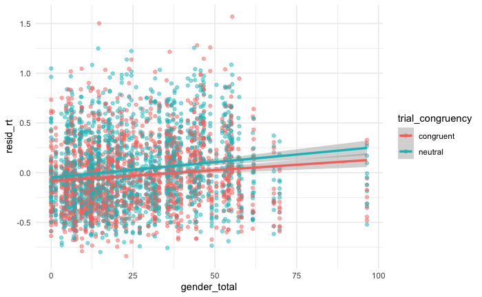

```r
ggplot(maze_data, aes(x=gender_total, y=resid_rt, color=trial_congruency)) +
  geom_point(alpha=.5) +
  geom_smooth(method = 'lm', size=1.2) +
  theme_minimal()
```

**Reading Time by Congruency & Gender**

```r
maze_speaker_means <- maze_data %>%
  group_by(condition,workerid) %>%
  summarize(MeanRT=mean(resid_rt))
```

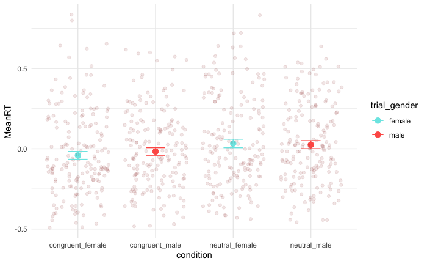

```r
maze_data %>%
  group_by(condition,trial_gender) %>%
  summarize(MeanRT = mean(resid_rt), CI.Low = ci.low(resid_rt), CI.High = ci.high(resid_rt)) %>%
  mutate(YMin = MeanRT - CI.Low, YMax = MeanRT + CI.High) %>%
  ggplot(aes(x=condition,y=MeanRT,color=trial_gender)) +
  geom_point(size=3) +
  geom_jitter(data = maze_speaker_means, aes(y=MeanRT),alpha=.1,color='darkred') +
  geom_errorbar(aes(ymin=YMin,ymax=YMax), width=.25) +
  scale_color_manual(values = bran_palette) +
  theme_minimal()
```

**Item Means**

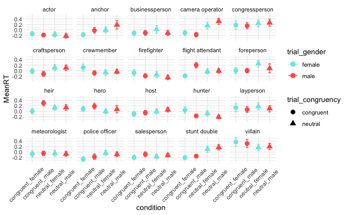

```r
maze_data %>%
  group_by(condition,trial_gender,trial_congruency,lexeme) %>%
  summarize(MeanRT = mean(resid_rt), CI.Low = ci.low(resid_rt), CI.High = ci.high(resid_rt)) %>%
  mutate(YMin = MeanRT - CI.Low, YMax = MeanRT + CI.High) %>%
  ggplot(aes(x=condition,y=MeanRT,color=trial_gender,shape=trial_congruency)) +
  geom_point(size=3) +
  geom_errorbar(aes(ymin=YMin,ymax=YMax), width=.25) +
  facet_wrap(~ lexeme) +
  theme(axis.text.x = element_text(angle = 45, vjust = .7, hjust=.7)) +
  scale_color_manual(values = bran_palette) +
  facet_wrap(~lexeme)
```

**Morphological Type and Gender**

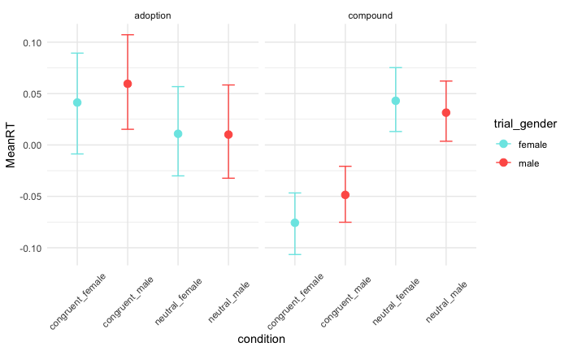

```r
maze_data %>%
  group_by(condition,trial_gender,morph_type) %>%
  summarize(MeanRT = mean(resid_rt), CI.Low = ci.low(resid_rt), CI.High = ci.high(resid_rt)) %>%
  mutate(YMin = MeanRT - CI.Low, YMax = MeanRT + CI.High) %>%
  ggplot(aes(x=condition,y=MeanRT,color=trial_gender)) +
  geom_point(size=3) +
  geom_errorbar(aes(ymin=YMin,ymax=YMax), width=.25) +
  scale_color_manual(values = bran_palette) +
  facet_wrap(~morph_type) +
  theme(axis.text.x = element_text(angle=45, vjust = 0.5))
```

**Model**

```r
maze_data <- maze_data %>%
  mutate(ctrial_congruency = as.numeric(as.factor(trial_congruency))-mean(as.numeric(as.factor(trial_congruency)))) %>%
  mutate(ctrial_gender = as.numeric(as.factor(trial_gender))-mean(as.numeric(as.factor(trial_gender)))) %>%
  mutate(cgender_link = scale(gender_link)) %>%
  mutate(cgender_total = scale(gender_total)) %>%
  mutate(cmorph_type = as.numeric(as.factor(morph_type))-mean(as.numeric(as.factor(morph_type)))) %>%
  mutate(cgender = as.numeric(as.factor(subject_information.gender))-mean(as.numeric(as.factor(subject_information.gender))))
```

```r
complex_model <- lmer(resid_rt~ctrial_congruency*ctrial_gender*cgender_total + (1|workerid) + (1|lexeme),data = maze_data)
```

```r
summary(complex_model)
```

```
Linear mixed model fit by REML. t-tests use Satterthwaite's method ['lmerModLmerTest']
Formula: resid_rt ~ ctrial_congruency * ctrial_gender * cgender_total +      (1 | workerid) + (1 | lexeme)
   Data: maze_data

REML criterion at convergence: 1235.7

Scaled residuals:
    Min      1Q  Median      3Q     Max
-3.2718 -0.6627 -0.0981  0.5897  4.1441

Random effects:
 Groups   Name        Variance Std.Dev.
 workerid (Intercept) 0.04665  0.2160
 lexeme   (Intercept) 0.01362  0.1167
 Residual             0.07193  0.2682
Number of obs: 3271, groups:  workerid, 175; lexeme, 20

Fixed effects:
                                                Estimate Std. Error         df t value Pr(>|t|)
(Intercept)                                    8.630e-03  3.114e-02  3.549e+01   0.277  0.78328
ctrial_congruency                              5.433e-02  9.412e-03  3.072e+03   5.773 8.58e-09 ***
ctrial_gender                                  1.003e-02  9.412e-03  3.072e+03   1.065  0.28676
cgender_total                                  4.962e-02  1.708e-02  1.712e+02   2.906  0.00415 **
ctrial_congruency:ctrial_gender               -2.322e-02  1.883e-02  3.072e+03  -1.233  0.21755
ctrial_congruency:cgender_total                1.411e-02  9.410e-03  3.072e+03   1.499  0.13386
ctrial_gender:cgender_total                   -1.066e-02  9.425e-03  3.073e+03  -1.131  0.25822
ctrial_congruency:ctrial_gender:cgender_total -1.067e-02  1.883e-02  3.072e+03  -0.567  0.57094
---
Signif. codes:  0 ‘***’ 0.001 ‘**’ 0.01 ‘*’ 0.05 ‘.’ 0.1 ‘ ’ 1

Correlation of Fixed Effects:
                 (Intr) ctrl_c ctrl_g cgndr_ ctrl_cngrncy:ct_ ctrl_cngrncy:cg_ ctrl_g:_
ctrl_cngrnc       0.000
ctrial_gndr       0.000 -0.003
cgender_ttl      -0.003  0.000  0.000
ctrl_cngrncy:ct_  0.000  0.000  0.001  0.000
ctrl_cngrncy:cg_  0.000  0.000 -0.001  0.001  0.000
ctrl_gndr:_       0.000  0.000  0.001  0.001 -0.001           -0.001
ctrl_cn:_:_       0.000  0.001 -0.001  0.001 -0.001            0.004            0.005
```

## 2.4 Production Task Study

### 2.4.1 Methods

### 2.4.2 Analysis

**Data Read-in**

```r
prod_data <- read.csv("production_data.csv")
```

**Exclusions**

```r
exclusion <- prod_data %>% filter(name=='attention') %>%
  group_by(workerid) %>%
  summarise(accuracy = mean(correct)) %>%
  mutate(exclude = ifelse(accuracy < 0.80,'Yes','No')) %>%
  filter(exclude == "Yes")
```

```r
prod_data <- prod_data[!(prod_data$workerid %in% exclusion$workerid),]
```

**Additional Information**

```r
prod_data <- prod_data %>%
  mutate(gender_trans = 100 - (rowMeans(prod_data[gender_transcendence_cols]))) %>%
  mutate(gender_link = rowMeans(prod_data[gender_linked_cols]))

gender_all = c('gender_trans','gender_link')

prod_data <- prod_data %>%
  mutate(gender_total = rowMeans(prod_data[gender_all]))
```

```r
prod_data <- prod_data %>%
  filter(type == "critical") %>%
  mutate(response_gender = ifelse(response == "actress" | response == "anchorwoman" | response == "stewardess" | response == "businesswoman" | response == 'camerawoman' | response == 'congresswoman' | response == 'craftswoman' | response == 'crewwoman' | response == 'firewoman' | response == 'forewoman'  | response == 'heiress' | response == 'heroine' | response == 'hostess' | response == 'huntress' | response == 'laywoman' | response == 'policewoman' | response == 'saleswoman' | response == 'stuntwoman' | response == 'villainess' | response == 'weatherwoman',"female",ifelse(response == "anchor" | response == "flight attendant" | response == "businessperson" | response == 'camera operator' | response == 'congressperson' | response == 'craftsperson' | response == 'crewmember' | response == 'firefighter' | response == 'foreperson' | response == 'layperson' | response == 'police officer' | response == 'salesperson' | response == 'stunt double' | response == 'meteorologist',"neutral",ifelse(response == "anchorman" | response == "steward" | response == "businessman" | response == 'cameraman' | response == 'congressman' | response == 'craftsman' | response == 'crewman' | response == 'fireman' | response == 'foreman' | response == 'layman' | response == 'policeman' | response == 'salesman' | response == 'stuntman' | response == 'weatherman',"male",'male/neutral')))) %>%
  mutate(congruency = ifelse(gender == response_gender,"true","false")) %>%
  mutate(neutrality = ifelse(response_gender == "neutral","true","false"))%>%
  mutate(morph_type = ifelse(lexeme!= 'actor' & lexeme!= 'host' & lexeme !='hunter' & lexeme!= 'villain' & lexeme!= 'heir' & lexeme!= 'hero','compound','adoption')) %>%
  mutate(poli_party = ifelse(subject_information.party_alignment == 1 | subject_information.party_alignment == 2,'Republican',ifelse(subject_information.party_alignment == 4 | subject_information.party_alignment == 5,'Democrat','Non-Partisan')))
```

**Responses by Political Ideology**

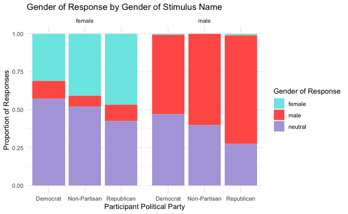

```r
prod_data %>%
  filter(!is.na(poli_party)) %>%
  filter(morph_type =="compound") %>%
  ggplot(aes(x=poli_party, fill=response_gender)) +
  geom_bar(position="fill") +
  facet_wrap(~gender) +
  scale_fill_manual(values = bran_palette) +
  labs(x="Participant Political Party", fill="Gender of Response", y="Proportion of Responses", title="Gender of Response by Gender of Stimulus Name")
```

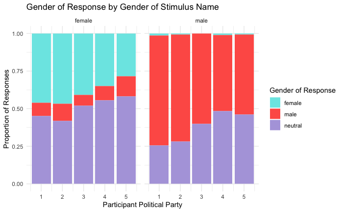

```r
prod_data %>%
  filter(!is.na(subject_information.party_alignment)) %>%
  filter(morph_type =="compound") %>%
  ggplot(aes(x=subject_information.party_alignment, fill=response_gender)) +
  geom_bar(position="fill") +
  facet_wrap(~gender) +
  scale_fill_manual(values = bran_palette) +
  labs(x="Participant Political Party", fill="Gender of Response", y="Proportion of Responses", title="Gender of Response by Gender of Stimulus Name")
```

**Gender of Response by Political Alignment and Gender Ideology**

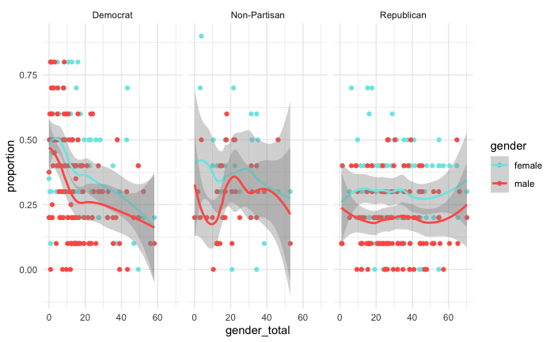

```r
prod_data %>%
  filter(!is.na(poli_party)) %>%
  mutate(response_neutral = ifelse(response_gender == "neutral",1,0)) %>%
  filter(gender!="filler" & gender!= "attention" & gender!="") %>%
  group_by(gender,gender_total,poli_party) %>%
  summarise(proportion = mean(response_neutral)) %>%
  ggplot(aes(x=gender_total, y=proportion, color=gender)) +
    geom_point() +
    geom_smooth() +
    scale_color_manual(values = bran_palette) +
    facet_wrap(~poli_party)
```

**Gender by Gender, no Ideology**

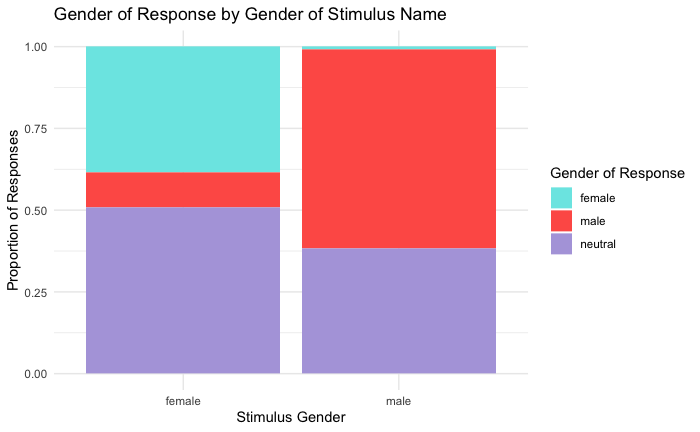

```r
prod_data %>%
  filter(morph_type =="compound") %>%
  ggplot(aes(x=gender, fill=response_gender)) +
  geom_bar(position="fill") +
  scale_fill_manual(values = bran_palette) +
  labs(x="Stimulus Gender", fill="Gender of Response", y="Proportion of Responses", title="Gender of Response by Gender of Stimulus Name") +
  theme_minimal()
```

**Models**

```r
prod_data_compounds <- prod_data %>%
  filter(morph_type == "compound") %>%
  mutate(cgender_total = scale(gender_total)) %>%
  mutate(response_congruency = as.numeric(ifelse(congruency=="true","1","0"))) %>%
  mutate(cage = scale(subject_information.age)) %>%
  mutate(neutrality_binary = ifelse(neutrality=="true",1,0))
```

```r
final_dat <- merge(prod_data_compounds,lex_freqs,by="lexeme") %>%
  mutate(neutrality_binary = ifelse(neutrality=="true",1,0)) %>%
  filter(morph_type == "compound") %>%
  mutate(cgender_total = scale(gender_total)) %>%
  mutate(response_congruency = as.numeric(ifelse(congruency=="true","1","0"))) %>%
  mutate(cage = scale(subject_information.age)) %>%
  mutate(cmean_left_neutral = scale(mean_left_neutral)) %>%
  mutate(mean_all = (mean_left_neutral + mean_right_neutral)/2) %>%
  mutate(cmean_all = scale(mean_all))
```

```r
production_model_one <- lmer(neutrality_binary~cgender_total + poli_party + gender + cmean_all + (1|workerid) + (1|lexeme) + (1|name),data=final_dat)
```

```r
summary(production_model_one)
```

```
Linear mixed model fit by REML. t-tests use Satterthwaite's method ['lmerModLmerTest']
Formula: neutrality_binary ~ cgender_total + poli_party + gender + cmean_all +      (1 | workerid) + (1 | lexeme) + (1 | name)
   Data: final_dat

REML criterion at convergence: 4017.5

Scaled residuals:
    Min      1Q  Median      3Q     Max
-2.7141 -0.6983 -0.1105  0.7911  2.9453

Random effects:
 Groups   Name        Variance  Std.Dev.
 workerid (Intercept) 0.0309677 0.1760
 name     (Intercept) 0.0003027 0.0174
 lexeme   (Intercept) 0.0632691 0.2515
 Residual             0.1481350 0.3849
Number of obs: 3822, groups:  workerid, 273; name, 24; lexeme, 14

Fixed effects:
                        Estimate Std. Error        df t value Pr(>|t|)
(Intercept)              0.55630    0.07029  14.08933   7.915 1.49e-06 ***
cgender_total           -0.05448    0.01378 269.10221  -3.954 9.84e-05 ***
poli_partyNon-Partisan  -0.04567    0.03909 269.03597  -1.168    0.244
poli_partyRepublican    -0.11824    0.02960 269.00650  -3.994 8.38e-05 ***
gendermale              -0.11708    0.01444  21.90517  -8.105 4.90e-08 ***
cmean_all                0.03832    0.06752  12.00057   0.567    0.581
---
Signif. codes:  0 ‘***’ 0.001 ‘**’ 0.01 ‘*’ 0.05 ‘.’ 0.1 ‘ ’ 1

Correlation of Fixed Effects:
            (Intr) cgndr_ pl_N-P pl_prR gndrml
cgender_ttl  0.084
pl_prtyNn-P -0.126 -0.110
pl_prtyRpbl -0.192 -0.444  0.327
gendermale  -0.103 -0.010  0.001  0.003
cmean_all    0.000  0.000  0.000  0.000  0.002
```